# Unify Dimensionality Reduction Results

Guangchuang Yu School of Basic Medical Sciences, Southern Medical University

2026-10-09

## Interface for dimensionality reduction methods

```r
library(tidydr)
x <- dr(data = iris[,1:4], fun = prcomp)
```

The `dr()` function apply the function, `fun`, and (if any) parameters to analyze the input ‘data’.

The data can be original data matrix (or data frame), or distance matrix (or distance object), depending on the requirement of the DR method (specify by the ‘fun’ parameter).

Methods supported by the `dr()` function can be listed via the `available_methods()`:

```r
available_methods()
```

```
## The `dr()` function works for the following methods that
## require data matrix (or data frame) as input:
##   +  stats::prcomp()
##   +  Rtsne::Rtsne()
##   +  uwot::umap()
##   +  uwot::tumap()
##   +  uwot::lvish()
```

```
## The `dr()` function works for the following methods that
## require distance matrix (or distance object) as input:
##   +  stats::cmdscale()
##   +  MASS::sammon()
##   +  vegan::metaMDS()
##   +  ape::pcoa()
##   +  smacof::mds()
##   +  vegan::wcmdscale()
##   +  ecodist::pco()
##   +  labdsv::pco()
##   +  ade4::dudi.pco()
##
## Note: any other function that returns a numeric matrix with
## at least two columns is also accepted (see `?dr_extract`).
## Some methods need their own arguments, which are passed through
## `...` of `dr()`, e.g. `dr(d, ade4::dudi.pco, scannf = FALSE)` or
## `dr(x, Rtsne::Rtsne, check_duplicates = FALSE)`.
## `ecodist::pco()` returns every eigenvector, so `dr()` keeps all
## n - 1 of them; use `Dim1`/`Dim2` for plotting.
```

The listing is grouped by the kind of input a method expects; `available_methods("data")` and `available_methods("distance")` show one group each:

```r
available_methods("distance")
```

```
## The `dr()` function works for the following methods that
## require distance matrix (or distance object) as input:
##   +  stats::cmdscale()
##   +  MASS::sammon()
##   +  vegan::metaMDS()
##   +  ape::pcoa()
##   +  smacof::mds()
##   +  vegan::wcmdscale()
##   +  ecodist::pco()
##   +  labdsv::pco()
##   +  ade4::dudi.pco()
##
## Note: any other function that returns a numeric matrix with
## at least two columns is also accepted (see `?dr_extract`).
## Some methods need their own arguments, which are passed through
## `...` of `dr()`, e.g. `dr(d, ade4::dudi.pco, scannf = FALSE)` or
## `dr(x, Rtsne::Rtsne, check_duplicates = FALSE)`.
## `ecodist::pco()` returns every eigenvector, so `dr()` keeps all
## n - 1 of them; use `Dim1`/`Dim2` for plotting.
```

A distance object is passed to `dr()` in the same way as a data matrix, and the result is visualized identically:

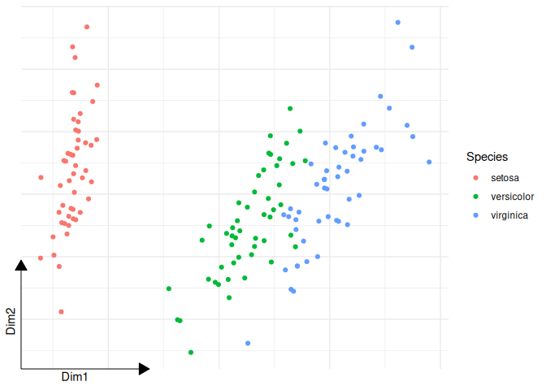

```r
d <- dist(iris[, 1:4])
y <- dr(d, stats::cmdscale)
autoplot(y, aes(color = Species), metadata = iris[, 5, drop = FALSE]) + theme_dr()
```

Some methods require their own arguments, which are passed through `...`:

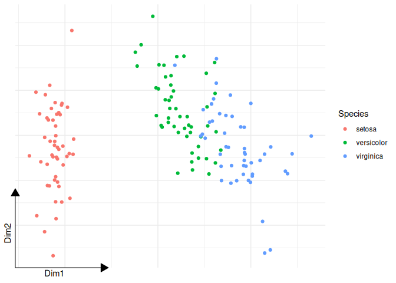

```r
autoplot(dr(iris[, 1:4], prcomp, scale. = TRUE),
         aes(color = Species), metadata = iris[, 5, drop = FALSE]) + theme_dr()
```

The same route carries arguments that a method needs to run non-interactively, e.g. `dr(iris[, 1:4], Rtsne::Rtsne, check_duplicates = FALSE)` or `dr(d, ade4::dudi.pco, scannf = FALSE)` – without `scannf = FALSE` that method stops at an interactive prompt. `available_methods()` repeats these reminders after the listing.

## Visualization

The `tidydr` package extends `ggplot()` to support the output of `dr()` function.

Associated data (e.g., group information) can be integrated to scale the color, shape or size of data points. The data should be provided via the `metadata` parameter. It allows a vector (will be stored in `.group`) or a data frame.

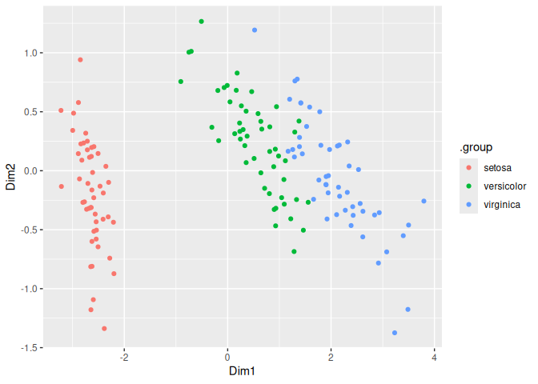

```r
library(ggplot2)
## metadata as a vector
ggplot(x, aes(Dim1, Dim2), metadata=iris$Species) +
  geom_point(aes(color=.group))
```

Users can use `autoplot()` as a shortcut. This package provide a theme, `theme_dr()`, to allow using shorten axes.

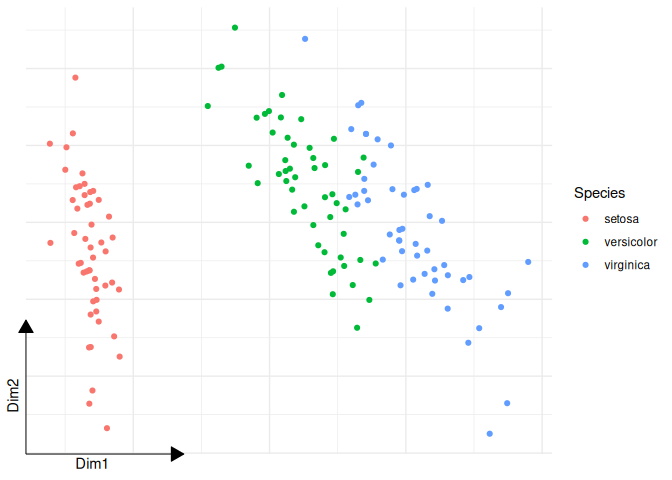

```r
## metadata as a data frame
autoplot(x, aes(color=Species), metadata = iris[, 5, drop=FALSE]) +
  theme_dr()
```

## Comparing several methods

`dr_compare()` applies several methods to the same data and returns them together. Each method is evaluated independently, so a method that fails is reported in the `summary` instead of aborting the whole call.

```r
r <- dr_compare(iris[, 1:4],
                funs = list(prcomp = stats::prcomp,
                            cmdscale = function(z) stats::cmdscale(dist(z))),
                dim = 1:2)
r$summary
```

```
##     method status   n k has_eigenvalue has_stress error
## 1   prcomp     ok 150 4           TRUE      FALSE  <NA>
## 2 cmdscale     ok 150 2          FALSE      FALSE  <NA>
```

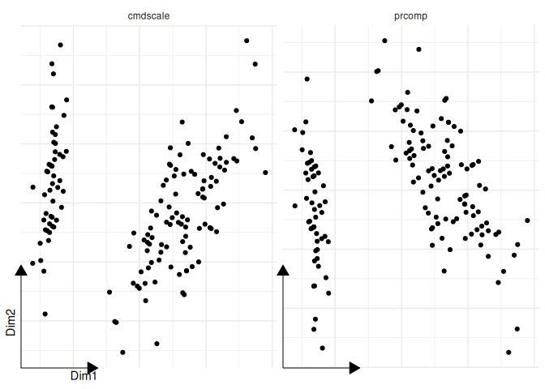

```r
autoplot(r) + theme_dr()
```

The `summary` lists which methods ran, how many dimensions each produced, and the error message of any method that did not.

## Clustering and silhouette widths

`nk()` computes the average silhouette width for one or more values of `k`. It uses `cluster::pam()` by default, and any other clustering function can be supplied through `fun`:

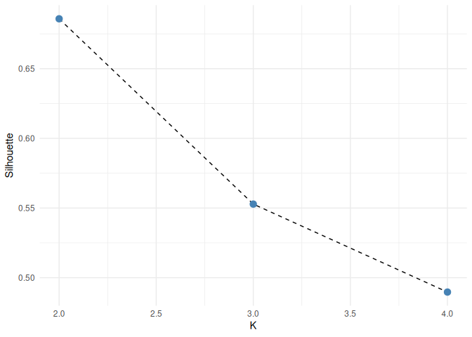

```r
si <- nk(iris[, 1:4], 2:4)
autoplot(si)
```

`fun` is given as a function, not a call. A method that takes the number of clusters as its second argument, or through an argument named `k` or `centers`, is used directly:

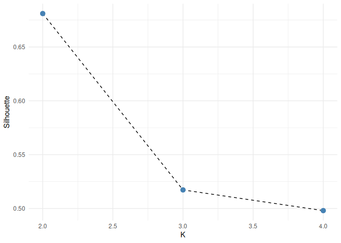

```r
si_km <- nk(iris[, 1:4], 2:4, fun = stats::kmeans)
autoplot(si_km)
```

A method that takes no cluster count, such as `stats::hclust()`, is fitted once and cut with `stats::cutree()` for each `k`:

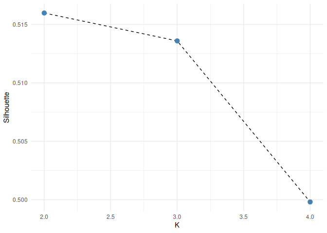

```r
si_hc <- nk(iris[, 1:4], 2:4, fun = stats::hclust)
autoplot(si_hc)
```

The silhouette width is computed with `cluster::silhouette()` for every clusterer except the default `pam()`, whose own silhouette information is reused; `silinfo_widths()` and `autoplot(type = "silhouette")` work the same way in either case.

Passing a `k` that is present in the object draws the samples in the reduced space, coloured by cluster:

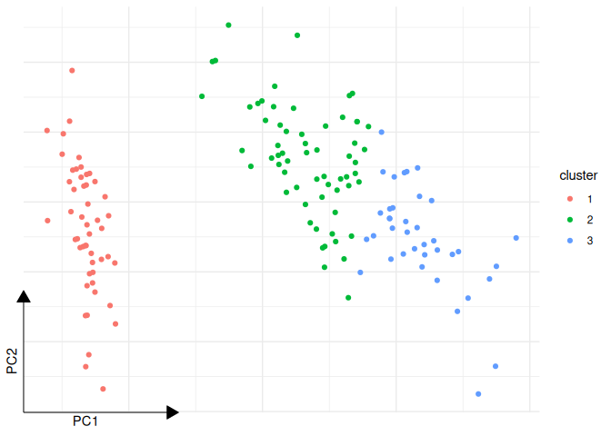

```r
autoplot(si, k = 3) + theme_dr()
```

The per-sample widths of a single `k` are available from `silinfo_widths()`. It returns a data frame, and the per-cluster averages are attached as an attribute:

```r
w <- silinfo_widths(si, 3)
head(w)
```

```
##   sample cluster neighbor sil_width
## 1      8       1        2 0.8539051
## 2      1       1        2 0.8529551
## 3     50       1        2 0.8520984
## 4     18       1        2 0.8510183
## 5     40       1        2 0.8503323
## 6     41       1        2 0.8494158
```

```r
attr(w, "clus.avg.widths")
```

```
## [1] 0.7981405 0.4173199 0.4511051
```

Setting `type = "silhouette"` draws the classic per-cluster silhouette bar plot:

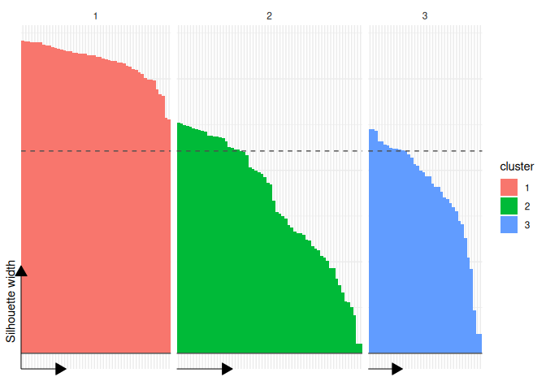

```r
autoplot(si, k = 3, type = "silhouette") + theme_dr()
```

## Method-specific information

A `dr_extract()` method may return a `sample_info` element alongside the coordinates. `fortify()` merges any element of `sample_info` that holds one value per sample into the returned data frame as an additional column, so it can be mapped in `aes()`. None of the `dr_extract()` methods shipped with `tidydr` returns one, so `sample_info` is `NULL` unless you write a method yourself; see `?dr` and `?dr_extract` for the details.